# Ampliando la red: son suficientes las transferencias extraordinarias para los trabajadores informales?

El caso de Argentina: AUH y el Ingreso Familiar Extraordinario

Martín Montané

2020-04-09

## Las políticas públicas en tiempos de COVID19: el caso del mercado de trabajo

La pandemia cambió las reglas del juego para los encargados de la política pública de todo el planeta. Medidas que hasta hace solo unas pocas semanas parecian ser extraordinarias [y hasta ilegales](https://www.top10vpn.com/news/surveillance/covid-19-digital-rights-tracker/), ahora forman parte del centro del debate público en torno qué hay que hacer para absorber el golpe, diseñar una salida ordenada que minimice los riesgos de recaìda, y repensar algunas políticas de cara al futuro para aumentar la resiliencia de nuestras economías.

En medio de este cambio fugaz de las reglas del juego, una realidad obvia del diseño de políticas públicas materializó en nuestras caras: *el diseño e implementación de las políticas depende de las propiedades de la economía*. Mientras que los países desarrollados, los primeros que recibieron el shock luego de que migrara desde China, pueden proteger los ingresos de sus ciudadanos con políticas que se diseñan desde la información y las obligaciones y derechos que las relaciones laborales dictan, en los países no desarrollados la protección del ingreso de sus ciudadanos tiene un punto ciego que obliga a [repensar los arreglos de políticas laborales luego de la crisis](https://econfip.org/policy-brief/work-after-covid-a-new-regime-for-independent-workers/#): la informalidad laboral.

## Los cuatro golpes a los trabajadores informales

Podemos simplificar el mundo de las relaciones laborales diciendo que existen tres formas de estar en relación con un empleador: asalariado registrado, asalariado no registrado y trabajadores independientes. En [otro documentos](https://www.utdt.edu//Upload/_156561758080852100.pdf) se explica con mayor detalle a qué hacemos referencia con cada uno de estos grupos, pero no está lejos a lo que la mayoría piensa cuando se suelen nombrar. El primer grupo son trabajadores en relación de dependencia que pagan aportes y contribuciones de acuerdo a la legislación laboral, el segundo grupo es un trabajador en relación de dependencia pero aportes y contribuciones no se realizan, mientra que el último grupo engloba relaciones que no son de relación de dependencia (en teoría).

Más allá de las desventajas y ventajas que tienen estas relaciones laborales entre sí (se suele argumentar una mayor estabilidad y beneficios en el caso de la relación asalariada registrada), lo cierto es que *mientras estén registradas el Estado es capaz de conocer el ingreso percibido*. Este beneficio que puede ser fácilmente olvidado implica que es más difícil para el Estado diseñar políticas laborales que, tanto en tiempos normales como excepcionales, logre generar una red de contención para este grupo de trabajadores *que en Argentina pueden representar aproximadamente 6 millones de personas, o un tercio del total de los trabajadores* (CGI y MTEySS)

Por otro lado, en la cuarentena y en el futuro mediato es probable que para la circulación sea preciso justificar estar en relación laboral con una empresa de determinado sector, lo cual es todavía más difícil para un trabajador asalariado no registrado o independiente. De esta manera, este grupo de trabajadores se encuentra perjudicado por cuatro vías:

- No existen mecanismos automáticos ni excepcionales a disposición para proteger de manera directa sus ingresos (por ejemplo, seguro de desempleo, REPRO o cualquier versión de un subsidio salarial)
- No existen datos individuales para conocer sus ingresos o lo largo de su relación laboral para usarlo como insumo de la política pública
- No tienen la posibilidad de justificar estar en una relación laboral con una empresa en una eventual flexibilización de la cuarentena actual.
- Las empresas pueden recibibr subsidios salariales a cambio de no echar trabajadores, lo cual es positivo para los asalariados registrados *pero perjudicial para los trabajadores independientes y asalariados no registrados*, ya que hace todavía más barato su despido con respecto a los asalariados registrados.

## La mano pragmática de los policy makers: transferencias a hogares que no son asalariados registrados

Dadas estás restricciones, existentes en todos los países no desarrollados del mundo, incluyendo obviamente a América Latina, en Argentina se anunció, entre otras medidas, dos que desde su diseño van directamente hacia este grupo de personas: los bonos de AUH y el Ingreso Familiar de Emergencia (IFE), que aun se encuentra tramitando en ANSES.

- *Bono de 3.000 pesos por beneficio de AUH, Asignación por Embarazo, y por hijo con discapacidad*. Este bono es bastante simple de implementar y explicar. Consiste en una transferencia de única vez y adicional a la asignación correspondiente por un monto de 3.000 pesos.
- *Ingreso Familiar de Emergencia*. Esta transferencia es un poco más compleja y su efectiva aplicación dependerá de la capacidad del Estado de definir un grupo familiar similar al reportado en las Encuestas de Hogares. Se trata de un monto, por única vez, de 10.000 pesos por hogar a todos los grupos familiares que:
  - No tengan ningúna persona trabajando en relación de dependencia (por las dudas, esto excluye al régimen especial de servicios domésticos)
  - No sean monotributistas de categoría C o superior y no sean autónomos
  - No tengan seguro de desempleo
  - No tengan jubilaciones o pensiones
  - No perciban planes sociales *excepto AUH, Asignación por embarazo y el programa Progresar*

¿Este conjunto de medidas alcanza para sustituir el ingreso que hubieran percibido los trabajadores que no se encuentran protegidos? ¿Son suficientes, al menos, para morigerar el shock que perciben?

## ¿Es la improvisada red suficiente?

En esta nota vamos a intentar responder esta pregunta usando los datos disponibles en la Encuesta Permanente de Hogares (EPH), una encuesta que el INDEC realiza de manera trimestral para conocer la evolución de los ingresos de las familias y personas de Argentina, entre otras muchas variables. Esta encuesta no está específicamente diseñada para estos ejercicios, por lo que vamos a dejar este disclaimer por acá.

Supongamos por un instante que la cuarentena dura hasta junio inclusive, y que los ingresos extra por AUH e IFE se repiten en mayo y junio. Por otro lado, supongamos que ninguno de los trabajadores y trabajadoras que se encuentran excluidos de la relación asalariada pueden trabajar y su ingreso es cero durante este período. Para aquellas personas que les guste entender datos a través de visualizaciones, en el gráfico de abajo muestro un escenario de qué hubiera pasado con la distribución de ingresos de los hogares con al menos algún ingreso de trabajadores vulnerables sí:

- El shock COVID19 no sucedía (distribución celeste)
- Escenario actual pero sin las medidas anunciadas por el gobierno (distribución violeta)
- Escenario actual proyectado (distribución amarilla)

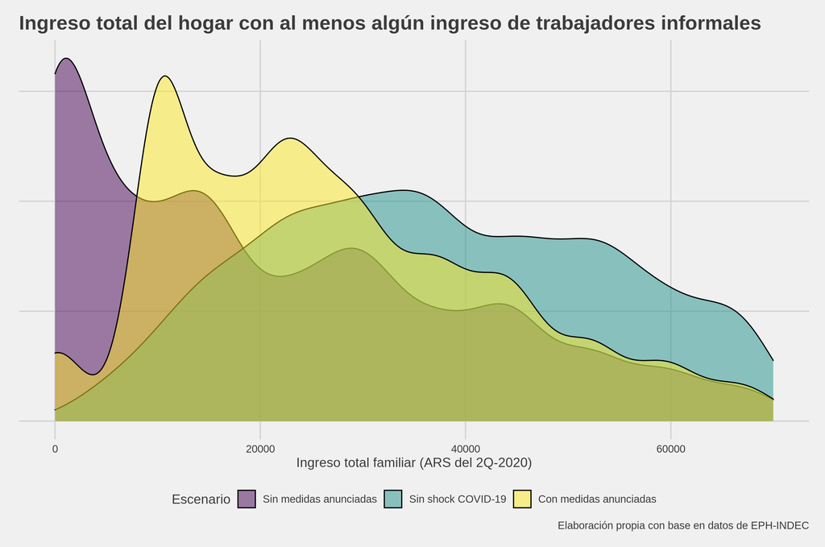

La primera conclusión que uno puede hacer de este gráfico es que, aun extendiendo estos beneficios durante mayo y junio, *en promedio estas familias no van a estar compensadas por lo que pierden en el mercado de trabajo*. Esto puede verse claramente con la diferencia que existe entre la distribución de ingresos celeste y la amarilla. Recuerden que, en el caso de un subsidio salarial, se podría mantener más fácilmente - aunque quizás a un mayor costo - el ingreso de los trabajadores asalariados registrados, cosa que esta versión de las políticas no puede garantizar.

La segunda conclusión es que *las medidas parecen ser eficientes como para alejar a los hogares de la parte inferior de la distribución de ingresos*. Esto implica que la extensión de la red alcanza a esta clase de trabajadores y trabajadoras, solo que para alejarlos un poco de la zona en la cual caerían en la situación de indigencia y pobreza, pero no lo suficiente como para mantener los ingresos anteriores.

## Afinando los números: ¿Cuánto mejora los ingresos?

Vamos con números que sean un poco más fácil de entender. Una pregunta razonable es cuánto ayuda a cada uno de los hogares estas transferencias del gobierno. Esto es difícil de responder dada la Encuesta Permanente de Hogares, pero tomémonos una licencia por COVID19. Si hacemos la cuenta por hogar de cual es la diferencia entre lo que percibirán en nuestro ejercicio entre abril y junio de 2020, versus lo que hubiera pasado sin el shock negativo, estos hogares estarán mucho peor: en promedio, *su ingreso total será un 30% menor*, lo que en promedio significa una caída de 22.000 pesos. Además, el 75% de los hogares de este grupo experimenta ingresos menores a los que hubiera percibido.

| Variable | COVID + Medidas (versus no COVID) | COVID + Medidas (versus COVID sin medidas) |
| --- | --- | --- |
| % de hogares con ingresos menores | 75% | No corresponde |
| Variación promedio en los hogares (%) | -30% | +25% |
| Variación promedio en los hogares (ARS) | - ARS 22.000 | + ARS 5.200 |

Quizás sea un objetivo de máxima cubrir todos los ingresos de este tipo de trabajadores, algo que sin embargo es posible de buscar y plausible de realizar en el corto plazo entre asalariados registrados. Veamos ahora, en cambio qué pasaría en el escenario en el cual el gobierno no anunciaba estas políticas, pero el shock COVID llegaba al mercado laboral. Tomándonos una nueva licencia, podemos concluir tentativamente que el ingreso promedio de estos hogares mejora un 25%, lo que en promedio significa aproximadamente ARS 5.000 adicionales por familia.

## Conclusión: la red protege bien a los vulnerables, pero no es un sustituto para progeter a los trabajadores

Nuestro ejercicio marca que si la cuarentena se extiende y las políticas del gobierno se repiten, un 75% de los hogares que tienen ingresos por trabajadores independientes o no asalariados experimentarán una caída en su ingreso. En promedio, estos hogares perderán el 30% de sus ingresos o aproximadamente 22.000 pesos mensuales durante abril y junio de 2020. Desde este punto de vista, estas “transferencias por la negativa” no son suficiente como para mantener los ingresos de los trabajadores que no son asalariados registrados.

Sin embargo, la política específica para Argentina parece ser efectiva para proteger a la parte más baja de la distribución, aunque en promedio de los hogares es una mejora de tan solo el 25% de los ingresos, o 5.200 pesos por mes. Se espera que esta medida, de ser correctamente implementada, sea útil para evitar que más gente caiga por debajo de la línea de indigencia y pobreza, lo cual es un objetivo primordial de corto plazo.